# Machine Learning Project

Plato Karageorgis

29/11/2021

### A Quick Intro

To begin the analysis, we will assign our data to local variables.

```r
train_data <- read.csv('C:/Users/Platon/Desktop/Coursera/pml-training.csv', header=T)
test_data <- read.csv('C:/Users/Platon/Desktop/Coursera/pml-testing.csv', header=T)
```

```r
set.seed(33000)
inTrain <- createDataPartition(y= train_data$classe, p=0.7, list=FALSE)
training <- train_data[inTrain, ]
testing <- train_data[-inTrain, ]
```

Now, we have to start “playing” with our data. The main problem here is that we have a lot of NA values. This affects us mostly on our test set and not so much on our training set, although if we want to be precise, we should do it on both. There are multiples ways to go. We could erase all of them but then we might have a problem with the quantity of the remaining data. Also, we could erase some of them randomly and uniformly. I will choose the simpler solution and erase all of them since we have a lot of data.

```r
nas <- sapply(names(test_data), function(x) all(is.na(test_data[,x])==TRUE))
nas_names <- names(nas)[nas==FALSE]
nas_names <- nas_names[-(1:7)]
nas_names <- nas_names[1:(length(nas_names)-1)]
fit <- trainControl(method='cv', number = 3)
```

### Algorithms

I will apply 2 algorithms to check if my model is working correctly. I will use Random Forest and Boosting Trees. Firstly, for the random forest algorithm:

```r
modelFitRF <- train(classe ~ ., data=training[, c('classe', nas_names)], trControl = fit, method='rf',ntree=70)
```

And for the prediction:

```r
predictFitRF <- predict(modelFitRF, testing, type = "raw")
```

And moving on the GBM algorithm:

```r
modelFitGBM <- train(classe ~ ., data=training[, c('classe', nas_names)], trControl = fit, method='gbm')
```

And for the prediction:

```r
predictFitGBM <- predict(modelFitGBM, testing, type = "raw")
```

### Plots

Moving on, I will do some very simple plots with the plot() function in order to visualize the accuracies.

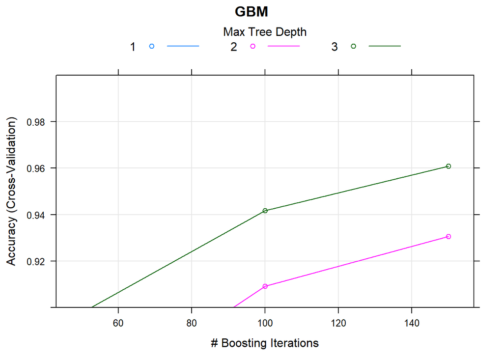

```r
plot(modelFitGBM, ylim = c(0.9, 1), main= "GBM")
```

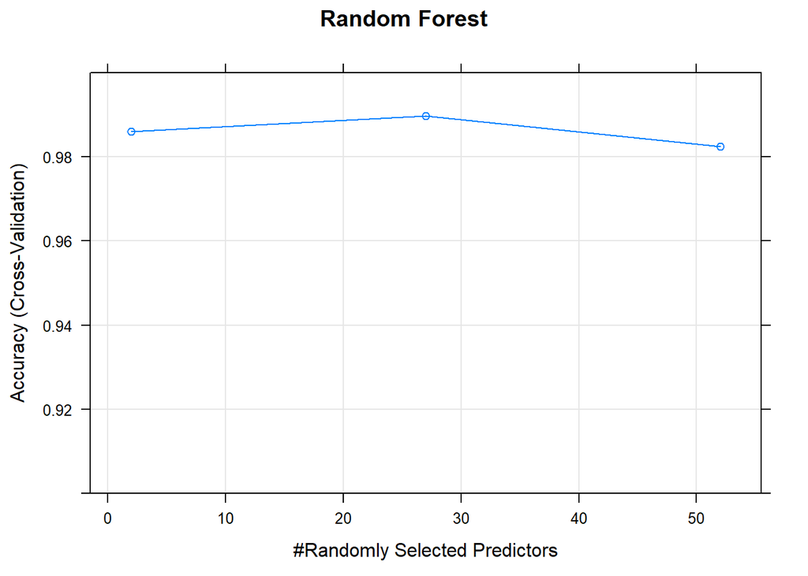

```r
plot(modelFitRF, ylim = c(0.9, 1),main= "Random Forest")
```

### Results

Moreover, I am creating a confusion matrix exactly like the ones shown in the lectures in order to see the exact values of the accuracies.

```r
confusionGBM <- confusionMatrix(predictFitGBM, as.factor(testing$classe))
confusionRF <- confusionMatrix(predictFitRF, as.factor(testing$classe))

accuracy <- data.frame(Model = c('RF', 'GBM'),Accuracy = rbind(confusionRF$overall[1], confusionGBM$overall[1]))
print(accuracy)
```

```
##   Model  Accuracy
## 1    RF 0.9935429
## 2   GBM 0.9639762
```

### Final Predictions

Last but not least, the 20 predictions that the exercise requests. I will use Random Forest since it was better.

```r
predictions <- predict(modelFitRF, newdata=test_data)
final <- data.frame(problem_id= test_data$problem_id, predicted=predictions)
print(final)
```

```
##    problem_id predicted
## 1           1         B
## 2           2         A
## 3           3         B
## 4           4         A
## 5           5         A
## 6           6         E
## 7           7         D
## 8           8         B
## 9           9         A
## 10         10         A
## 11         11         B
## 12         12         C
## 13         13         B
## 14         14         A
## 15         15         E
## 16         16         E
## 17         17         A
## 18         18         B
## 19         19         B
## 20         20         B
```

### Conclusion

We can clearly see that the random forest algorithm is more than capable of predicting the right values from the plots but even more clearly on our matrix. The GBM model takes is also running quite impressively. You can see the results on the .html file.